# CH4 聚类分析

聚类分析是一种典型的无监督学习， 用于对未知类别的样本进行划分，将它们按照一定的规则划分成若干个类族，把相似(距高相近)的样本聚在同一个类簇中， 把不相似的样本分为不同类簇，从而揭示样本之间内在的性质以及相互之间的联系规律.

[figure not shown]

聚类的目标是得到较高的簇内相似度和较低的簇间相似度，使得簇间的距离尽可能大，簇内样本与簇中心的距离尽可能小。

聚类算法在银行、零售、保险、医学、军事等诸多领域有着广泛的应用。

学习聚类实现方法、聚类效果评价指标。重点介绍基于划分的方法、基于密度的方法、基于层次的方法等方法。

### 4.1 聚类方法分类

```
基于划分的聚类

基于层次的聚类

基于密度的聚类

基于网格的聚类

基于模型的聚类
```

### 4.2 良好聚类算法的特征

```
良好的可伸缩性

处理不同类型数据的能力

处理噪声数据的能力

对样本顺序的不敏感性

约束条件下的表现

易解释性和易用性
```

### 4.3 聚类分析的度量

聚类得到的簇可以用聚类中心、簇大小、簇密度和簇描述等来表示

```
 聚类中心是一个簇中所有样本点的均值(质心)

 簇大小表示簇中所含样本的数量

 簇密度表示簇中样本点的紧密程度

 簇描述是簇中样本的业务特征
```

度量指标用于对聚类结果进行评判，分为内部指标和外部指标两大类：

外部指标指用事先指定的聚类模型作为参考来评判聚类结果的好坏； 内部指标是指不借助任何外部参考，只用参与聚类的样本评判聚类结果好坏。

#### 1.外部指标

对于含有𝑛个样本点的数据集𝑆，其中的两个不同样本点𝑥_𝑖, 𝑥_𝑗 ，假设𝐶是聚类算法给出的簇划分结果，𝑃是外部参考模型给出的簇划分结果。那么对于样本点𝑥_𝑖,𝑥_𝑗来说，存在以下四种关系：

```
𝑆𝑆：𝑥_𝑖,𝑥_𝑗在𝐶和𝑃中属于相同的簇。

𝑆𝐷：𝑥_𝑖,𝑥_𝑗在𝐶中属于相同的簇，在𝑃中属于不同的簇。

𝐷𝑆：𝑥_𝑖,𝑥_𝑗在𝐶中属于不同的簇，在𝑃中属于相同的簇。

𝐷𝐷：𝑥_𝑖,𝑥_𝑗在𝐶和𝑃中属于不同的簇。
```

令𝑎,𝑏,𝑐,𝑑分别表示𝑆𝑆,𝑆𝐷,𝐷𝑆,𝐷𝐷所对应的关系数目，由于𝑥_𝑖,𝑥_𝑗之间的关系必定存在于四种关系中的一种，且仅能存在一种关系。

[figure not shown]

以上四个度量指标的值越大，表明聚类结果和参考模型直接的划分结果越吻合，聚类结果就越好

### 2. 内部指标

不借助外部参考模型，利用样本点和聚类中心之间的距离来衡量聚类结果的好坏。 常用的距离度量有欧氏距离、曼哈顿距离、切比雪夫距离和明可夫斯基距离等。

[figure not shown]

根据空间中点的距离度量，可以得出以下聚类性能度量内部指标😎

[figure not shown]

## 4.4 聚类方法

### 一、基于划分的方法

通过将对象划分为互斥的簇进行聚类， 每个对象属于且仅属于一个簇

常用算法有k-means、k-medoids、k-prototype等

### 1. K-Means 聚类

其核心思想是: 对于给定的样本集， 按照样本点之间的距离大小，将样本集划分为K个簇，并 让簇内的点尽量紧凑，而让簇间的点尽量分开。

k-均值算法聚类步骤如下： (1)首先选取𝑘个类簇（𝑘需要用户进行指定）的质心，通常是随机选取。 (2)对剩余的每个样本点，计算它们到各个质心的欧式距离，并将其归入到相互间距离最小的质心所在的簇。计算各个新簇的质心。 (3)在所有样本点都划分完毕后，根据划分情况重新计算各个簇的质心所在位置，然后迭代计算各个样本点到各簇质心的距离，对所有样本点重新进行划分。 (4)重复第（2）步和第（3）步, 直到迭代计算后，所有样本点的划分情况保持不变，此时说明k-均值算法已经得到了最优解，将运行结果返回

K-means 反复提炼初始评估的类中心，步骤如下： (1) 以随机或猜测的方式初始化类中心ui，i=1…k； (2) 将每个数据点归并到离它距离最近的类中心所属的类ci； (3) 对所有属于该类的数据点求平均，将平均值作为新的类中心； (4) 重复步骤（2）和步骤（3）直到收敛。

[figure not shown]

如下图所示，以K=2为例:我们需要将图(a)中的样本点划分为两类，则K-Means 聚类过程如下。 第1 步:从M 个数据对象中任意选择2个对象作为初始聚类中心，图( b)所示。 第2 步:计算每个对象到这两个聚类中心的距离，把各样本划分到与它们最近的中心所代表的类别中去，如图(c) 所示，并计算当前状态下的损失值。 第3 步: 计算各类别所包含点的均值点，将其作为新的类别中心，如图（d)所示。 第4 步:重复第2 步和第3 步， 直到连续两次的损失值相差为某一设定值为止。

可以看到， 虽然刚开始时是随机选择的两个点作为初始聚类中心，但经过反复迭代第2 步和第3 步后，最终聚类中心会逐渐趋于稳定，如图(f)所示:聚类中心稳定后，所有样本点的划分也会趋于稳定，从而达到比较理想的聚类效果。

[figure not shown]

#### K-Means聚类涉及四个关键点， 即聚类簇数K值的选择、K个聚类中心点的初始值选择、距离度量方式、损失函数的选择。

[figure not shown]

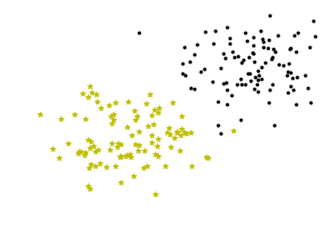

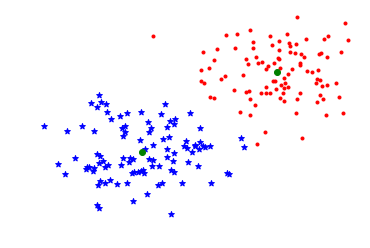

[output not shown]

```python
from sklearn.cluster import KMeans
import numpy as np
import matplotlib.pyplot as plt
class1 = 1.5 * np.random.randn(100,2) #100个2维点，标准差1.5正态分布
#print(class1)
class2 = 1.5*np.random.randn(100,2) + np.array([5,5])#标准正态分布平移5，5

#print(features)
plt.figure(0)
plt.scatter(class1[:,0],class1[:,1],c='y',marker='*')
plt.scatter(class2[:,0],class2[:,1],c='k',marker='.')
plt.axis('off')
plt.show()

features = np.vstack((class1,class2))
est = KMeans(n_clusters=2)
est.fit(features)

plt.figure(1)
#plt.scatter(features[:,0],features[:,1],c=est.labels_)

ndx = np.where(est.labels_==0)#print(ndx)
plt.scatter(features[ndx,0],features[ndx,1],c='b',marker='*')
ndx = np.where(est.labels_==1)
plt.scatter(features[ndx,0],features[ndx,1],c='r',marker='.')
plt.scatter(est.cluster_centers_[:,0],est.cluster_centers_[:,1],c='g',marker='o')

plt.axis('off')
plt.show()
```

[figure not shown]

2 . 样本数据较大时 传统的K-Means 算法中，需要计算所有的样本点到所有聚类中心的距离，如果样本量较大，则这个过程将非常耗时。而大数据时代，这样的场景越来越多，因此研究者提出K-Means 算法的另一种改进版--Mini Batch KMeans 就是在做K-Means 算法前先对大样本数据进行一个随机采样(一般是无放回的) ，对来样得到的样本再用K-Means 算法进行聚类。为了提高聚类的准确性， 一般进行多次Mini Batch后再进行多次K-Means 聚类，最后选择最优的聚类簇。

### 利用sklearn库应用k-均值聚类算法

```python
sklearn.cluster.KMeans(n_clusters=8,max_iter=300,init='k-means++',n_init=10 ,
algorithm='auto',random_state=None)
参数:
    • n_clusters : 即K值， 一般需要多试一些值，以获得较好的聚类效果。
    • max_iter: 最大法代次数，默认为300 。
    • init:选择初始化聚类中心的方式,可选k-means++或random,默认是k-means++,建议默认.
    • n_init: 指定选择不同的初始化聚类中心运行算法的次数，默认是10。由于K-Means的结果是受初始值影响的局部最优法代算法，因此一般需要多选择几组初始聚类中心进行尝试，最后选择最好的结果作为最终聚类结果。
    • algorithm:选择距离度量算法，有auto、full和elkan 三种选择。full表示使用二范数度量距离;elkan表示使用elkan K-Means算法，当数据比较稠密时，选择该算法可以减少计算。一般建议默认的auto，让其自动选择。
    • random_state : 用于产生初始化聚类中心的随机化种子。

属性
    • cluster_centers_ : 输出各个聚类中心向量。
    • labels_: 输出各个簇的标签。
    • inertia_:所有样本点到其最近点距离之和。
方法
    • fit(X): 训练聚类模型。
    • fit_predict(X) : 在X上执行数据集，返回样本X的簇标记。
    • predict(X): 预测样本集X中每个样本最接近的簇。
```

#### 示例：使用sklearn.cluster.KMeans实现对Iris数据集进行聚类

首先引用相应的库，其中sklearn.cluster为sklearn中已经实现的聚类算法工具包

```python
#Demo_4_1.py
import numpy as np
import matplotlib.pyplot as plt
from mpl_toolkits.mplot3d import Axes3D
from sklearn.cluster import KMeans
from sklearn import datasets
plt.rcParams['font.sans-serif']=['SimHei'] #用来正常显示中文标签
plt.rcParams['axes.unicode_minus']=False #用来正常显示负号
```

从IRIS数据集中加载鸢尾花样本信息到X和y两个变量中，其中，X存放花瓣长宽等特征，y存放花的类别标签。构造并初始化K-均值模型，设置类簇数量为3类，调用fit方法执行聚类

```python
#np.random.seed(5)  #随机种子
iris = datasets.load_iris()
X = iris.data
y = iris.target
est = KMeans(n_clusters=3)
est.fit(X)

print(est.labels_)#簇标签
print(est.cluster_centers_)#簇中心向量，簇标签0，1，2对应
print(est.predict([[5.9016129,2.7483871,4.39354839,1.43387097],
                  [5.006,3.428,1.462,0.246],
                  [6.85,3.07368421,5.74210526,2.07105263]]))
print(est.predict(X[:50]))#分组准确情况
print(est.predict(X[50:100]))
print(est.predict(X[100:150]))
#保存训练好的模型
#import joblib
#joblib.dump(est, "yyb.pkl")
```

```
[1 1 1 1 1 1 1 1 1 1 1 1 1 1 1 1 1 1 1 1 1 1 1 1 1 1 1 1 1 1 1 1 1 1 1 1 1
 1 1 1 1 1 1 1 1 1 1 1 1 1 0 0 2 0 0 0 0 0 0 0 0 0 0 0 0 0 0 0 0 0 0 0 0 0
 0 0 0 2 0 0 0 0 0 0 0 0 0 0 0 0 0 0 0 0 0 0 0 0 0 0 2 0 2 2 2 2 0 2 2 2 2
 2 2 0 0 2 2 2 2 0 2 0 2 0 2 2 0 0 2 2 2 2 2 0 2 2 2 2 0 2 2 2 0 2 2 2 0 2
 2 0]
[[5.9016129  2.7483871  4.39354839 1.43387097]
 [5.006      3.428      1.462      0.246     ]
 [6.85       3.07368421 5.74210526 2.07105263]]
[0 1 2]
[1 1 1 1 1 1 1 1 1 1 1 1 1 1 1 1 1 1 1 1 1 1 1 1 1 1 1 1 1 1 1 1 1 1 1 1 1
 1 1 1 1 1 1 1 1 1 1 1 1 1]
[0 0 2 0 0 0 0 0 0 0 0 0 0 0 0 0 0 0 0 0 0 0 0 0 0 0 0 2 0 0 0 0 0 0 0 0 0
 0 0 0 0 0 0 0 0 0 0 0 0 0]
[2 0 2 2 2 2 0 2 2 2 2 2 2 0 0 2 2 2 2 0 2 0 2 0 2 2 0 0 2 2 2 2 2 0 2 2 2
 2 0 2 2 2 0 2 2 2 0 2 2 0]
```

对聚类的结果可视化显示，使用Axes3D将其显示在3维空间中，其中花瓣宽度、萼片长度、花瓣长度分别作为x,y,z三个维度

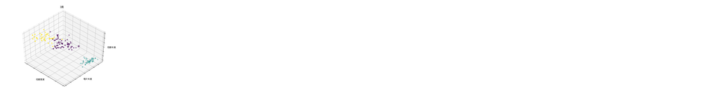

```python
fig = plt.figure(1, figsize=(8, 6))
ax = Axes3D(fig, rect=[0, 0, .95, 1], elev=48, azim=134)
ax.scatter(X[:, 3], X[:, 0], X[:, 2],c=est.labels_)#标签做颜色值
ax.w_xaxis.set_ticklabels([])
ax.w_yaxis.set_ticklabels([])
ax.w_zaxis.set_ticklabels([])
ax.set_xlabel('花瓣宽度')
ax.set_ylabel('萼片长度')
ax.set_zlabel('花瓣长度')
ax.set_title("3类")
ax.dist = 12
plt.show()
```

```python
# 调用保存好的模型(训练好的)去做预测
model = joblib.load("yyb.pkl")
print(model.predict([[5.9016129,2.7483871,4.39354839,1.43387097],
                  [5.006,3.428,1.462,0.246],
                  [6.85,3.07368421,5.74210526,2.07105263]]))
```

```
[0 1 2]
```

k-均值算法不适用于非凸面形状（非球形）的数据集，例如图中例子，k-均值算法的聚类结果就与初始目标有非常大的差别

[figure not shown]

使k-均值聚类时，需要注意如下问题： 模型的输入数据为数值型数据（如果是离散变量，需要作哑变量处理） 需要将原始数据作标准化处理（防止不同量纲对聚类产生影响） 对k值的选取，主要有以下几种： 与层次聚类算法结合，先通过层次聚类算法得出大致的聚类数目，并且获得一个初始聚类结果，然后再通过k-均值算法改进聚类结果 基于系统演化的方法，将数据集视为伪热力学系统，在分裂和合并过程中，将系统演化到稳定平衡状态从而确定k值

### 2. k-medoids算法

k-均值算法簇的聚类中心选取受到噪声点的影响很大，因为噪声点与其他样本点的距离远，在计算距离时会严重影响簇的中心。k-medoids 算法克服了k-均值算法的这一缺点， k -medoids算法不通过计算簇中所有样本的平均值得到簇的中心，而是通过选取原有样本中的样本点作为代表对象代表这个簇，计算剩下的样本点与代表对象的距离，将样本点划分到与其距离最近的代表对象所在的簇中. 距离计算过程与k均值算法的计算过程类似，只是将距离度量中的中心替换为代表对象.

围绕中心点划分(Partitioning Around Mediods, PAM) 算法是k -medoids聚类的一种典型实现。PAM 算法中簇的中心点是一个真实的样本点而不是通过距离计算出来的中心。

### 3. k-prototype算法

k-prototype算法的聚类过程与k-均值算法相同，只是在聚类过程中引入参数𝛾来控制数值属性和分类属性的权重。

## 二、基于密度聚类

基于划分聚类和基于层次聚类的方法在聚类过程中根据距离来划分类簇，因此只能够用于挖掘球状簇。

为了解决这一缺陷，基于密度聚类算法利用密度思想，将样本中的高密度区域(即样本点分布稠密的区域)划分为簇，将簇看作是样本空间中被稀疏区域(噪声)分隔开的稠密区域。这一算法的主要目的是过滤样本空间中的稀疏区域，获取稠密区域作为簇基于密度的聚类算法是根据密度而不是距离来计算样本相似度，所以基于密度的聚类算法能够用于挖掘任意形状的簇，并且能够有效过滤掉噪声样本对于聚类结果的影响。

常见的基于密度的聚类算法有DBSCAN、OPTICS和DENCLUE等。其中，OPTICS 对DBSCAN算法进行了改进，降低了对输入参数的敏感程度。DENCLUE算法综合了基于划分、基于层次的方法。

### DBSCAN聚类算法

DBSCAN（Density-Based Spatial Clustering of Applications with Noise，具有噪声的基于密度的聚类方法）是一种基于密度的空间聚类算法。

该算法将具有足够密度的区域划分为簇，并在具有噪声的空间数据库中发现任意形状的簇，它将簇定义为密度相连的点的最大集合。样本密度大的成一类，这就是DBSCAN聚类算法。

DBSCAN采用基于中心的密度定义，样本的密度通过核心对象在𝜖半径内的样本点个数(包括自身)来估计。DBSCAN算法基于领域来描述样本的密度，输入样本集𝑆={𝑥_1,𝑥_2,…,𝑥_𝑚 }和参数(𝜀,𝑀𝑖𝑛𝑃𝑡𝑠)刻画邻域的样本分布密度。其中，𝜀表示样本的邻域距离阈值，𝑀𝑖𝑛𝑃𝑡𝑠表示对于某一样本𝑝，其𝜖-邻域中样本个数的阈值。

下面给出DBSCAN中的几个重要概念。

1. 𝝐-邻域：给定对象𝑥_𝑖，在半径𝜀内的区域称为𝑥_𝑖的𝜀-邻域。在该区域中，𝑆的子样本集𝑁_𝜖(𝑥_𝑖 )={𝑥_𝑗∈𝑆|𝑑𝑖𝑠𝑡𝑎𝑛𝑐𝑒〖(𝑥〗_𝑖,𝑥_𝑗)≤𝜀}。
2. 核心对象（core object）：如果对象𝑥_𝑖∈𝑆，其𝜖-邻域对应的子样本集𝑁_𝜖(𝑥_𝑖)至少包含𝑀𝑖𝑛𝑃𝑡𝑠个样本，|𝑁_𝜖 (𝑥_𝑖 )|≥𝑀𝑖𝑛𝑃𝑡𝑠,那么𝑥_𝑖为核心对象.
3. 直接密度可达（directly density-reachable）：对于对象𝑥_𝑖和𝑥_𝑗，如果𝑥_𝑖是一个核心对象，且𝑥_𝑗在𝑥_𝑖的𝜀-邻域内，那么对象𝑥_𝑗是从𝑥_𝑖直接密度可达的。
4. 密度可达（density-reachable）：对于对象𝑥_𝑖和𝑥_𝑗，若存在一个对象链𝑝_1,𝑝_2,…,𝑝_𝑛，使得𝑝_1=𝑥_𝑖,𝑝_𝑛=𝑥_𝑗，并且对于𝑝*𝑖 (1≤𝑖≤𝑛), 𝑝*(𝑖+1)从𝑝_𝑖关于(𝜀,𝑀𝑖𝑛𝑃𝑡𝑠)直接密度可达，那么𝑥_𝑗是从𝑥_𝑖密度可达的。
5. 密度相连（density-connected）：对于对象𝑥_𝑖和𝑥_𝑗，若存在𝑥_𝑘使得𝑥_𝑖和𝑥_𝑗是从𝑥_𝑘关于(𝜀,𝑀𝑖𝑛𝑃𝑡𝑠)密度可达，那么𝑥_𝑖和𝑥_𝑗是密度相连的。

具体步骤: 1.先建立几个集合，一个用来存储核心对象的集合Ω，初始值是空集；再初始化一个值k，用来存放簇的类别数，初始值为0；再新建一个集合Γ，用来存放未被使用的样本，初始值为全部样本集D。

2.遍历所有样本集中的每个样本点p，判断其是否满足核心对象的条件，如果满足，则把该点加入到核心对象集合Ω中；如果没有样本点满足核心对象条件，则结束遍历。

3.判断核心对象集合Ω是否为空，如果为空，则算法结束；如果不为空，则在集合Ω中随机选取一个样本点，将该点密度可达的所有样本点划分为一个簇，这个簇的样本集合称为Ck ，将簇的类别数k+1，未被使用样本Γ-Ck。

4.再在剩余的核心对象中重复步骤3，直到没有核心对象为止。

5.最后输出k个类别的样本集合{C1、C2、……、Ck}。

https://www.naftaliharris.com/blog/visualizing-dbscan-clustering/

[figure not shown]

```python
class sklearn.cluster.DBSCAN(eps=0.5, min_samples=5, metric='euclidean',
     metric_params=None, algorithm='auto', leaf_size=30, p=None, n_jobs=1)
eps:即邻域中的r值，可以理解为圆的半径。
min_samples:要成为核心对象的必要条件，即邻域内的最小样本数，默认是5个。
metric:距离计算方式，和层次聚类中的affinity参数类似，同样也可以是precomputed。
metric_params:其他度量函数的参数。
algorithm:最近邻搜索算法参数，auto、ball_tree(球树)、kd_tree（kd树）、brute(暴力搜索)，默认是auto。
leaf_size:最近邻搜索算法参数，当algorithm使用kd_tree或者ball_tree时，停止建子树的叶子节点数量的阈值。
p: 最近邻距离度量参数。只用于闵可夫斯基距离和带权重闵可夫斯基距离中p值的选择，p=1为曼哈顿距离，p=2为欧式距离。

对象/属性
core_sample_indices_：核心对象数。
labels_：每个样本点的对应的类别，对于噪声点将赋值为-1。
```

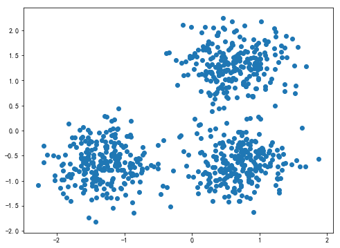

```
3
 2    245
 1    244
 0    243
-1     18
dtype: int64
```

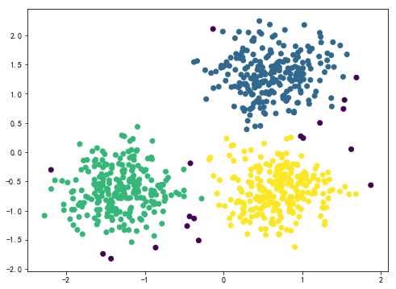

```python
from sklearn.cluster import DBSCAN
from sklearn import metrics
#from sklearn.datasets.samples_generator import make_blobs
from sklearn.datasets import make_blobs
from sklearn.preprocessing import StandardScaler
import numpy as np
import matplotlib.pyplot as plt
plt.rcParams['font.sans-serif']=['SimHei'] #用来正常显示中文标签
plt.rcParams['axes.unicode_minus']=False #用来正常显示负号
centers = [[1, 1], [-1, -1], [1, -1]]
X,ltrue=make_blobs(n_samples=750,centers=centers,cluster_std=0.4,random_state=0)
X = StandardScaler().fit_transform(X)###
plt.figure(0, figsize=(8, 6))
plt.scatter( X[:, 0], X[:, 1])
plt.show()

model = DBSCAN(eps=0.3, min_samples=10)
db=model.fit(X)
labels = db.labels_
n_clusters_ = len(set(labels)) - (1 if -1 in labels else 0)
print(n_clusters_)
# 统计每一类的数量
import pandas as pd
counts = pd.value_counts(model.fit_predict(X),sort=True)
print(counts)

plt.figure(1, figsize=(8, 6))
plt.scatter( X[:, 0], X[:, 1],c=db.labels_)
plt.show()
```

[figure not shown]

```python
from sklearn import metrics
# 计算轮廓系数
score = metrics.silhouette_score(X,model.fit_predict(X))
score
```

```
0.6255247640253795
```

## 三、基于层次聚类

层次聚类（hierarchical clustering）方法把数据组织成若干簇，并形成一个相应的树状图进行聚类。 按照层次聚类的过程分为自底向上的聚合聚类和自顶向下的分裂聚类。 聚合聚类以AGNES、BIRCH、ROCK等算法为代表，分裂聚类以DIANA算法为代表。 目前大多数是自底向上的聚合聚类，自顶向下的分裂聚类比较少

聚合层次聚类（凝聚层次聚类）采用自底向上的策略，首先把每个对象单独作为一类，然后根据一定的规则，例如把簇间距离最小的相似簇合并成为越来越大的簇，直到所有样本凝聚成一个大的簇，针对给定应用选择最好结果的聚类层次。

与聚合型方法相反，分裂聚类采用自顶向下的方法，先把所有的对象都看成一个簇，然后不断分解直至满足一定的条件。

[figure not shown]

AgglomerativeClustering是用来实现凝聚法聚类模型的。

class sklearn.cluster.AgglomerativeClustering (n_clusters=2, affinity='euclidean', memory=None, connectivity=None, compute_full_tree='auto', linkage='ward', pooling_func=<function mean at 0x174b938>)

n_clusters：目标类别数，默认是2。 affinity：样本点之间距离计算方式，可以是euclidean(欧式距离), l1、 l2、manhattan(曼哈顿距离)、cosine(余弦距离)、precomputed(可以预先设定好距离)，如果参数linkage选择“ward”的时候只能使用euclidean。 linkage：链接标准，即样本点的合并标准，主要有ward、complete、average三个参数可选，默认是ward。每个簇（类）本身就是一个集合，我们在合并两个簇的时候其实是在合并两个集合，所以我们需要找到一种计算两个集合之间距离的方式，主要有这三种方式：ward、complete、average，分别表示使用两个集合方差、两个集合中点与点距离之间的平均值、两个集合中距离最小的两个点的距离。

对象/属性 labels_:每个样本点的类别。 n*leaves*:层次树中叶结点树。

```
[0 0 0 1 0 0 0 1 0 0 0 1 0 0 0 1] 16
```

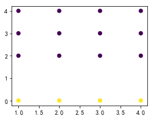

```
0    12
1     4
dtype: int64
```

```python
from sklearn.cluster import AgglomerativeClustering
import numpy as np

X = np.array([[1, 2],[1, 3], [1, 4], [1, 0],[2, 2],[2, 3], [2, 4], [2, 0],
              [3, 2],[3, 3],  [3, 4], [3, 0],[4, 2],[4, 3],[4, 4], [4, 0]])
clustering = AgglomerativeClustering().fit(X)

print(clustering.labels_,clustering.n_leaves_)

import matplotlib.pyplot as plt
plt.figure(1, figsize=(4, 3))
plt.scatter( X[:, 0], X[:, 1],c=clustering.labels_)
plt.show()

# 统计每一类的数量
import pandas as pd
counts = pd.value_counts(clustering.fit_predict(X),sort=True)
print(counts)
```

### 四、基于模型的聚类

基于模型的聚类包括基于概率模型的聚类和基于神经网络模型的聚类，其中大多数都是基于概率模型的聚类（如GMM）。

基于概率模型的聚类

1. 用高斯混合模型(GMM)的最大期望(EM)聚类 GMM聚类采用概率模型来表达原型，即通过统计得到每个样本点属于各个类的概率，而不是判定它完全属于一个类，也会被称为软聚类。

主要步骤如下：

(1)选择簇的数量，并随机初始化每个簇的高斯分布参数(即均值和方差)。

(2)给定每个簇的高斯分布，计算每个数据点属于每个簇的概率。一个点越靠近高斯分布的中心就越可能属于该簇。

(3)计算高斯分布参数，使概率最大化(EM最大期望)，可用数据点概率的加权计算这些新的参数，权重就是数据点属于该簇的概率。

重复迭代步骤2和3，直到迭代中的变化不大。

```python
import numpy as np
from sklearn import datasets
import matplotlib.pyplot as plt
from sklearn.mixture import GaussianMixture
from sklearn.cluster import KMeans
# 创建数据，并可视化
X,y = datasets.make_blobs(n_samples=1500,
                             cluster_std=[1.0, 2.5, 0.5],
                             random_state=170)
plt.figure(figsize=(12,4))
plt.rcParams['font.family'] = 'STKaiti'
plt.rcParams['font.size'] = 20
plt.subplot(1,3,1)
plt.scatter(X[:,0],X[:,1],c = y)
plt.title('原始数据',pad = 20)

# Kmeans聚类
kmeans = KMeans(3)
kmeans.fit(X)
y_ = kmeans.predict(X)
plt.subplot(1,3,2)
plt.scatter(X[:,0],X[:,1],c = y_)
plt.title('KMeans聚类效果',pad = 20)

# GMM高斯混合模型聚类
gmm = GaussianMixture(n_components=3)
y_ = gmm.fit_predict(X)
plt.subplot(1,3,3)
plt.scatter(X[:,0],X[:,1],c = y_)
plt.title('GMM聚类效果',pad = 20)

plt.figtext(x = 0.51,y = 1.1,s = 'KMeans VS GMM',ha = 'center',fontsize = 30)
plt.savefig('./GMM高斯混合模型.png',dpi = 200)
```

[output not shown]